# ipayipi rainfall data pipeline: imbibe to processed

20 February, 2025

# Summary

This vignette serves as protocol for the processing of event-based rainfall data. The steps below cover imbibing, standardisation, and processing—corresponding code to realise these steps are below. Data processing is done in R ‘iPayipi’. The data were collected using Hobo-data loggers installed in Texas tipping-bucket rain gauges.

1. Load `R ipayipi` (install from [GitHub](https://github.com/SAEONData/ipayipi)),
2. Initiate pipeline,
3. Imbibe data,
4. Standardise data,
5. Make station files,
6. Identify gaps, &
7. Process data.

The overview below shows code needed to execute the steps above. Each of these steps are further described in the following sections of this vignette. For more details and options for each step, see respective function documentation/help files in R. The help files serve as documentation protocol for each function used in ‘ipayipi’.

```r
## 1. load pacakge
library(ipayipi)

## 2. initiate pipeline housing ----
# define the general working directory: wherever data is going to be processed ...
wd <- "ipayipi_vignettes/rainfall_eg"

# setup pipeline directory structure
pipe_house <- ipip_house(work_dir = wd)

## 3. read & imbibe in data ----
logger_data_import_batch(pipe_house)
imbibe_raw_batch(pipe_house, data_setup = ipayipi::hobo_data)

## 4. standardise data ----
header_sts(pipe_house)
phenomena_sts(pipe_house)

## store standardised data ----
# transfer standardised data to the nomvet_room
transfer_sts_files(pipe_house)

## 5. append standardised data files ----
append_station_batch(pipe_house)

## 6. summarise gaps ----
gap_eval_batch(pipe_house)

## 7. Process data ----
dt_process_batch(pipe_house = pipe_house, pipe_seq = pipe_seq)
```

# Introduction

This vignette serves as a protocol for processing rainfall data, largely from Texas tipping-bucket rain gauges using R `ipayipi`. `ipayipi` facilitates a dynamic and structured pipeline so that processing down a pipeline (and up again), is traceable.

# Initiate pipeline: the ‘pipe_house’

The ‘pipe_house’ is the name of the directory structure wherein a data-pipeline is maintained. By initiating the pipeline, a number of directories will be created for ‘housing’ data at various stages of archival and processing, as well as storing scripts, and reports.

To start off, the *relative* directory where processing is going to done must be defined.

```r
# setting up the 'pipe_house'
## define pipeline working directory 'wd' (must be reletive)

phd <- "ipayipi_vignettes/rainfall_eg"

## initiate pipeline
pipe_house <- ipip_house(pipe_house_dir = phd)
print(pipe_house)
```

```
## $r
##                                 r
## "ipayipi_vignettes/rainfall_eg/r"
##
## $source_room
##                                 source_room
## "ipayipi_vignettes/rainfall_eg/source_room"
##
## $wait_room
##                                 wait_room
## "ipayipi_vignettes/rainfall_eg/wait_room"
##
## $nomvet_room
##                                 nomvet_room
## "ipayipi_vignettes/rainfall_eg/nomvet_room"
##
## $ipip_room
##                                 ipip_room
## "ipayipi_vignettes/rainfall_eg/ipip_room"
##
## $dta_out
##                                 dta_out
## "ipayipi_vignettes/rainfall_eg/dta_out"
##
## $reports
##                                 reports
## "ipayipi_vignettes/rainfall_eg/reports"
##
## $raw_room
##                                 raw_room
## "ipayipi_vignettes/rainfall_eg/raw_room"
##
## $pipe_house_dir
## [1] "ipayipi_vignettes/rainfall_eg"
```

What has `ipip_house()` done? It has created the following directories, if they don’t already exist*:

1. ‘r’: Folder for r scripts. Note the ‘pipe_seq’ folder contained therein—this will be used to store parameters for processing data later in the pipeline.
2. ‘source_room’: where ‘new’/incoming logger data is going to be made available.
3. ‘wait_room’: waiting room for imbibing & standarising data coming into the pipeline.
4. ‘nomvet_room’: where standardised/corrected logger files get archived (**nom**enclature **vet**ted).
5. ‘ipip_room’: here data get appended into single station records, and processed.
6. ‘dta_out’: Folder to which processed data can be exported in csv format.
7. ‘reports’: Folder for general reports, e.g., references or markdown documents.
8. ‘raw_room’: where ‘unaltered’ raw data gets pushed.

*NB! *Running this function will not overwrite existing data*.

# Imbibe data

In this step, incoming data gets pulled from pipelines data source, that is, the ‘source room’ (`pipe_house$source_room`), into the ‘waiting room’ (`pipe_house$wait_room`). The example data contains multiple years of hobo-rainfall data exports from [SAEON](https://www.saeon.ac.za) rainfall stations in northern Maputaland, South Africa.

```r
# copy data from source to the wait_room
logger_data_import_batch(pipe_house = pipe_house)
```

Now that some data is in the ‘wait_room’ directory we can read it into R. Note the ‘data_setup’ option for Hobo-data logger file exports `ipayipi::hobo_rain`. Also the `record_interval_type` has been set to ‘event_based’; options include ‘mixed’ and ‘continuous’. Use ‘event_based’ for hobo data (including cases where it is ‘mixed’ to cater for changes in future outputs). More on this below.

```r
imbibe_raw_batch(pipe_house = pipe_house,
  data_setup = ipayipi::hobo_rain, # standard for reading hobo file exports
  record_interval_type = "event_based"
)
```

For additional insight into data-input formats, that is, the ‘data_setup’ argument, *see* the help files of the `imbibe_raw_logger_dt()` function (i.e., `?imbibe_raw_logger_dt`). The `ipayipi::ipayipi::hobo_rain` caters for three variations in format associated with Hoboware exports. These three variations allow the import of hundreds of differently formatted (unencrypted) Hobo data file exports, and more variations can be added.

Record-interval type is an important parameter. `ipayipi` handles **continuous**, **event-based** (discontinuous), and **mixed** time-series data types. Record intervals get evaluated using the `record_interval_eval()` function. Record interval information will be important for further steps, such as, identifying ‘gaps’ or missing data automatically. More on this below.

# Standardise data

Both file-header information, plus other phenomena (variable) metadata, will now be standardised. The spelling/synonyms of file names and associated header metadata have to be scrutinised first. Only after header information gets standardised can we move onto the phenomena.

```r
# standardise header nomenclature
header_sts(pipe_house)
```

```
## ℹ There are unconfirmed identities in the nomenclature!
## ℹ Remember all lower case characters and no spaces, use '_'.
## → Check the following mandatory nomenclature fields:
## • 'location': two to four letter code for project area;
## • 'station': name of the station WITH station type suffix.
##   Station-type suffices: '_aws' = automatic weather station;
##   '_bt' = atmospheric pressure - barometer;
##   '_ct' = conductivity and temperature
##   '_cdt' = conductivity, depth, and temperature;
##   '_ec' = eddy-covariance);
##   '_rn' = rain gauge;
##   '_sr' = surface renewal;
##   '_dt' = depth, and temperature sensor.
## • 'stnd_title' (A concatenation of the location and station (with suffix))
## • 'record_interval_type'; one of the following: 'event_based', 'mixed', or 'continuous', see `?record_interval_eval` for more details.
## • 'record_interval': this will habe been guessed by `?record_interval_eval`). NB! For 'event_based' data 'record_interval' == 'discnt'.
## • 'table_name': standardised table name for raw data. For 'event_based' rainfall data the pipeline standard is 'raw_rain', and for continuous data a concatenation of 'raw_' and the `record_interval` is standard.
## ℹ An 'uz_' preffix indicates the 'unstandardised' mandatory fields/columns captured from data import/imbibe header info and imbibe 'data_setup' options.
## ℹ The following rows of the 'nomtab' have columns with 'NA' value(s) that requires populating: 56
```

```
##    uz_station location station stnd_title  logger_type logger_title uz_record_interval_type uz_record_interval record_interval_type record_interval uz_table_name table_name
##        <char>   <char>  <char>     <char>       <char>       <char>                  <char>             <char>               <char>          <char>        <char>     <char>
## 1:  Date_Time     <NA>    <NA>       <NA> hobo_pendant         <NA>             event_based             discnt                 <NA>            <NA>     hobo_data     raw_NA
```

```
##
## ℹ A csv version of the 'nom_tab has been generated here:
##   ipayipi_vignettes/rainfall_eg/wait_room/aa_nomtab_20250220_16h22.csv
## ✔ Fill out the NA fields and re-run `header_sts()`.
```

If it is the first-time running `header_sts()`, or new synonyms get introduced into pipe-house directory, `header_sts()` will produce a warning. This normally happens when a station name is adjusted a loggr program, or a new station is introduced into the pipeline, the pipeline then needs to define the new-nomenclature standards.

Unstandardised names (or columns) have the preffix ‘**uz**’. These standards get stored in a file called ‘nomtab.rns’ in the ‘waiting room’. *If this file is deleted—a new one will be generated—but the user will have to populate the tables with synonym vocab*.

The nomenclature table in the ‘waiting room’ can be updated from the csv file (or directly in R). If a new synonym gets introduced—the file containing new nomenclature will be skipped in further processing—a ‘csv’ version of the ‘nomtab.rns’ will be copied to the ‘waiting room’ for editing.

*Only the following fields* — with `NA`s — *require editing in the ‘nomtab’ ‘csv’:*

Examine the header nomenclature for the example data below. Only the columns highlighted in blue must be edited.

| uz_station | location | station | stnd_title | logger_type | logger_title | uz_record_interval_type | uz_record_interval | record_interval_type | record_interval | uz_table_name | table_name |
| --- | --- | --- | --- | --- | --- | --- | --- | --- | --- | --- | --- |
| Plot Title: Coastal Cashews | mcp | coastal_cashews_rn | mcp_coastal_cashews_rn | hobo_pendant | NA | event_based | discnt | event_based | discnt | hobo_data | raw_rain |
| Plot Title: Mseleni TC | mcp | mabasa_tc_rn | mcp_mabasa_tc_rn | hobo_pendant | NA | event_based | discnt | event_based | discnt | hobo_data | raw_rain |
| Manz_Office | mcp | manz_office_rn | mcp_manz_office_rn | hobo_pendant | NA | event_based | discnt | event_based | discnt | hobo_data | raw_rain |
| Plot Title: Sileza | mcp | sileza_camp_rn | mcp_sileza_camp_rn | hobo_pendant | NA | event_based | discnt | event_based | discnt | hobo_data | raw_rain |
| Plot_Title_Coastal_Cashews | mcp | coastal_cashews_rn | mcp_coastal_cashews_rn | hobo_pendant | NA | event_based | discnt | event_based | discnt | hobo_data | raw_rain |
| Plot_Title_Coastal_cashews | mcp | coastal_cashews_rn | mcp_coastal_cashews_rn | hobo_pendant | NA | event_based | discnt | event_based | discnt | hobo_data | raw_rain |
| Plot_Title_Manz_Office | mcp | manz_office_rn | mcp_manz_office_rn | hobo_pendant | NA | event_based | discnt | event_based | discnt | hobo_data | raw_rain |
| Plot_Title_Mseleni_TC | mcp | manz_office_rn | mcp_manz_office_rn | hobo_pendant | NA | event_based | discnt | event_based | discnt | hobo_data | raw_rain |
| Plot_Title_Sileza_Camp | mcp | sileza_camp_rn | mcp_sileza_camp_rn | hobo_pendant | NA | event_based | discnt | event_based | discnt | hobo_data | raw_rain |
| Plot_Title_Sileza_camp | mcp | sileza_camp_rn | mcp_sileza_camp_rn | hobo_pendant | NA | event_based | discnt | event_based | discnt | hobo_data | raw_rain |
| Plot_title_Manz_Office | mcp | manz_office_rn | mcp_manz_office_rn | hobo_pendant | NA | event_based | discnt | event_based | discnt | hobo_data | raw_rain |
| Plot_title_Mseleni_TC | mcp | mabasa_tc_rn | mcp_mabasa_tc_rn | hobo_pendant | NA | event_based | discnt | event_based | discnt | hobo_data | raw_rain |
| Sileza_Camp | mcp | sileza_camp_rn | mcp_sileza_camp_rn | hobo_pendant | NA | event_based | discnt | event_based | discnt | hobo_data | raw_rain |

Scrolling up and down the table above we see that we are dealing with four different rain gauges or ‘stations’. However, in the raw data there are multiple synonyms for each station’s standard title. The supplied ‘table name’, visible scrolling to the right, will be the name of the table for associated raw data in an ‘ipayipi’ station file; the standard title field will form the file name of the station. Standardising these fields as in the table above is important for further processing of the data.

Once `NA` values of the above fields have been populated the edited ‘csv’ will be imbibed into the pipeline structure when rerunning `header_sts(pipe_house)`—this function will imbibe the most recently updated ‘csv’ nomenclature table from the ‘wait_room’ into the pipeline, and standardised header nomenclature.

**Tip**: Double-check your nomenclature standards in the ‘csv’ file before running `header_sts()` again!

*In step with good [tidy data](https://www.tidyr.tidyverse.org/articles/tidy-data.html) standards, keep nomenclature to ‘snake case’ with no special characters (bar the useful underscore’).*

Standardising *phenomena* metadata follows a similar process as for header-data standardisation. If the phenomena standards have been described and there is a ‘phentab.rps’ in the ‘waiting room’, running the below code updates all files phenomena details.

```r
# standardise phenomena
phenomena_sts(pipe_house = pipe_house)
```

**Tip**: Setting the `remove_dups` argument to `TRUE` in `phenomena_sts()` allows the user to interactively remove, through a prompt interface, duplicate phenomena, on the off change logger exports have included these. Any interactive (via the prompt line) functionality is only possibly if parallel processing is sequential. See the section on parallel processing at the end.

If there is no ‘phenomena table’ (‘phentab.rps’), one `NA` values in the ‘csv’ copy need to be described. The following fields in the ‘csv’ phentab must be populated:

- phen_name_full: A descriptive name of the phenomenon (variable).
- phen_type: the type of phenomena (e.g., atmospheric pressure).
- phen_name: the name (used as a column header) of the phenomena. Must be created to avoid duplications.
- units: the measurement unit, e.g., bars.
- measure: describes how sampling has been done over/at the sampling interval, e.g., mean, min, sample, etc.

Additional fields that are not mandatory include:

- f_convert: A numeric multiplier that will be applied to this phenomena. Useful for converting from unstandardised to standardised units.

If an ‘f_convert’ factor (*scroll right on the table below*) is applied to phenomena, the standardised units must be different from the unstandardised units (uz_units) in the phenomena table. This ensures that phenomena that are appended have similar units.

| phen_name_full | phen_type | phen_name | units | measure | offset | var_type | uz_phen_name | uz_units | uz_measure | f_convert | sensor_id | notes |
| --- | --- | --- | --- | --- | --- | --- | --- | --- | --- | --- | --- | --- |
| Interference event: coupler attached | Interference event | attached | event | event | NA | fac | Coupler Attached | no_spec | no_spec | NA | NA | NA |
| Interference event: coupler attached | Interference event | attached | event | event | NA | fac | Coupler Attached (LGR S/N: 20102559) | no_spec | no_spec | NA | NA | NA |
| Interference event: bad battery | Interference event | bad_battery | event | event | NA | fac | Bad Battery (LGR S/N: 20116793) | no_spec | no_spec | NA | NA | NA |
| Interference event: host connected | Interference event | connected | event | event | NA | fac | Host Connected | no_spec | no_spec | NA | NA | NA |
| Interference event: host connected | Interference event | connected | event | event | NA | fac | Host Connected (LGR S/N: 20102559) | no_spec | no_spec | NA | NA | NA |
| Interference event: coupler detached | Interference event | detached | event | event | NA | fac | Coupler Detached | no_spec | no_spec | NA | NA | NA |
| Interference event: end of file | Interference event | end_of_file | event | event | NA | fac | End Of File | no_spec | no_spec | NA | NA | NA |
| Precipitation: total rainfall | Precipitation | rain_cumm | mm | cumm | 0 | num | Event, mm (LGR S/N: 20112169, SEN S/N: 20112169) | no_spec | no_spec | NA | NA | NA |
| Precipitation: total rainfall | Precipitation | rain_cumm | mm | cumm | 0 | num | Rainfall (mm) #20102559 | no_spec | no_spec | NA | NA | NA |
| Interference event: stopped | Interference event | stopped | event | event | NA | fac | Stopped (LGR S/N: 20102559) | no_spec | no_spec | NA | NA | NA |

After filling in details, to replace `NA` values (only in columns highlighted blue!), rerun `phenomena_sts(pipe_house)`, to imbibe the updated phenomena descriptions, and update the logger data.

Standardised data files get transferred to the ‘nomenclature vetted’ directory (‘nomtab room’) using the function below. After being transferred, files in the waiting room (except the nomtab and phentab standards) are automatically removed.

Note in the ‘waiting room’ how the file extension of files change as they are standardised. Successfully imbibed files have a ‘ipr’ extension. Post header standardisation the extension changes to ‘iph’; the extension becomes ‘ipi’ when phenomena synonyms are corrected.

```r
# move standardised files to a storage directory
transfer_sts_files(pipe_house)
```

**Archiving raw data files**: Before removing raw unstandardised files—if there is a ‘raw_room’ directory in the pipeline working directory—raw input data files will be copied to this directory and filed in folders by year and month of the lasted date of recording. This is done by the `imbibe_raw_batch()` function.

**Notes on the phenomena standards**: Apart from the usual ‘rain_cumm’ phenomena where the cumulative total of rainfall ‘tips’ are summed, hobo logger systems document ‘interference’ events. Interference events denote when loggers were ‘interacted’ with in the field, e.g., ‘host connected’ or ‘attached’ for when a download cable is attached to the logger. This information will be useful for processing the data later on.

# Make station files

The `append_station_batch()` function updates station files in the ‘ipip_room’ with files from the ‘nomvet_room’. `append_station_batch()` optimises ‘non-NA’ data retention between overlapping ‘date-time’ stamps. An important consideration for Hobo-data logger exports that can differ depending on the computing system environment.

```r
# append station files + metadata records
append_station_batch(pipe_house, verbose = TRUE)
```

Now that station files have been generated lets examine what has been done so far. Station files are maintained in the ‘ipip_room’ of the pipeline’s folder structure.

```r
# list station files in the ipip directory
sflist <- dta_list(
  input_dir = pipe_house$ipip_room, # search directory
  file_ext = ".ipip", # note the station's default file extension
)

# check what stations are in the ipip room
print(sflist)
```

```
## [1] "mcp_coastal_cashews_pr.ipip" "mcp_mabasa_tc_pr.ipip"       "mcp_manz_office_pr.ipip"     "mcp_sileza_camp_pr.ipip"
```

```r
# read in the station file
sf <- readRDS(file.path(pipe_house$ipip_room, sflist[1]))

# names of the tables stored in the station file
names(sf)
```

```
##  [1] "data_summary"       "dt_1_days_agg"      "dt_1_days_agg_saws" "dt_1_hours_agg"     "dt_1_months_agg"    "dt_1_years_agg"     "dt_5_mins_agg"      "dt_pseudo_event"    "dt_rain"            "dt_rain_se"         "f_params"           "gaps"
## [13] "logg_interfere"     "meta_events"        "phen_data_summary"  "phens"              "phens_dt"           "pipe_seq"           "pseudo_events"      "raw_rain"
```

## ‘Raw’ data

Our station file has one ‘raw’ data table, the ‘raw_rain’ table, composed of the event data below.

```r
# a look at the first few data rows
head(sf$raw_rain)
```

```
##       id           date_time attached connected detached end_of_file rain_cumm stopped
##    <num>              <POSc>   <fctr>    <fctr>   <fctr>      <fctr>     <num>  <fctr>
## 1:     1 2019-01-14 16:17:19                                             0.000
## 2:     2 2019-01-14 16:18:30                      Logged                    NA
## 3:     3 2019-01-16 06:23:18                                             0.254
## 4:     4 2019-01-16 06:28:15                                             0.508
## 5:     5 2019-01-16 06:36:08                                             0.762
## 6:     6 2019-01-16 11:24:44                                             1.016
```

## The ‘raw’ data-header summary

This table contains summary information on the origin of each data file used to make up the station file.

| dsid | file_format | uz_station | location | station | stnd_title | start_dttm | end_dttm | logger_type | logger_title | logger_sn | logger_os | logger_program_name | logger_program_sig | uz_record_interval_type | uz_record_interval | record_interval_type | record_interval | dttm_inc_exc | dttm_ie_chng | uz_table_name | table_name | nomvet_name | file_origin | logg_interfere |
| --- | --- | --- | --- | --- | --- | --- | --- | --- | --- | --- | --- | --- | --- | --- | --- | --- | --- | --- | --- | --- | --- | --- | --- | --- |
| 1 | hobo_csv_export | Plot_Title_Coastal_Cashews | mcp | coastal_cashews_pr | mcp_coastal_cashews_pr | 2019-01-14 16:17:19 | 2019-03-13 14:07:53 | hobo_pendant | NA | 20116788 | NA | NA | NA | event_based | discnt | event_based | discnt | TRUE | FALSE | hobo_data | raw_rain | mcp_coastal_cashews_pr_discnt_20190114-20190313__1.ipi | NA | on_site |
| 2 | hobo_csv_export | Plot_Title_Coastal_Cashews | mcp | coastal_cashews_pr | mcp_coastal_cashews_pr | 2019-01-14 16:17:19 | 2019-04-11 13:50:38 | hobo_pendant | NA | 20116788 | NA | NA | NA | event_based | discnt | event_based | discnt | TRUE | FALSE | hobo_data | raw_rain | mcp_coastal_cashews_pr_discnt_20190114-20190411__1.ipi | NA | on_site |
| 3 | hobo_csv_export | Plot_Title_Coastal_Cashews | mcp | coastal_cashews_pr | mcp_coastal_cashews_pr | 2019-01-14 16:17:19 | 2019-05-15 09:27:29 | hobo_pendant | NA | 20116788 | NA | NA | NA | event_based | discnt | event_based | discnt | TRUE | FALSE | hobo_data | raw_rain | mcp_coastal_cashews_pr_discnt_20190114-20190515__1.ipi | NA | on_site |
| 4 | hobo_csv_export | Plot_Title_Coastal_Cashews | mcp | coastal_cashews_pr | mcp_coastal_cashews_pr | 2019-01-14 16:17:19 | 2019-07-09 09:03:39 | hobo_pendant | NA | 20116788 | NA | NA | NA | event_based | discnt | event_based | discnt | TRUE | FALSE | hobo_data | raw_rain | mcp_coastal_cashews_pr_discnt_20190114-20190709__1.ipi | NA | on_site |
| 5 | hobo_csv_export | Plot_Title_Coastal_Cashews | mcp | coastal_cashews_pr | mcp_coastal_cashews_pr | 2019-07-09 10:05:04 | 2019-08-13 15:21:31 | hobo_pendant | NA | 20116788 | NA | NA | NA | event_based | discnt | event_based | discnt | TRUE | FALSE | hobo_data | raw_rain | mcp_coastal_cashews_pr_discnt_20190709-20190813__1.ipi | NA | on_site |
| 6 | hobo_csv_export | Plot_Title_Coastal_Cashews | mcp | coastal_cashews_pr | mcp_coastal_cashews_pr | 2019-08-13 15:33:12 | 2019-09-11 11:43:00 | hobo_pendant | NA | 20116788 | NA | NA | NA | event_based | discnt | event_based | discnt | TRUE | FALSE | hobo_data | raw_rain | mcp_coastal_cashews_pr_discnt_20190813-20190911__1.ipi | NA | on_site |
| 7 | hobo_csv_export | Plot_Title_Coastal_Cashews | mcp | coastal_cashews_pr | mcp_coastal_cashews_pr | 2019-08-13 15:33:12 | 2019-10-09 08:53:19 | hobo_pendant | NA | 20116788 | NA | NA | NA | event_based | discnt | event_based | discnt | TRUE | FALSE | hobo_data | raw_rain | mcp_coastal_cashews_pr_discnt_20190813-20191009__1.ipi | NA | on_site |
| 8 | hobo_csv_export | Plot_Title_Coastal_Cashews | mcp | coastal_cashews_pr | mcp_coastal_cashews_pr | 2019-08-13 15:33:12 | 2019-11-13 09:23:40 | hobo_pendant | NA | 20116788 | NA | NA | NA | event_based | discnt | event_based | discnt | TRUE | FALSE | hobo_data | raw_rain | mcp_coastal_cashews_pr_discnt_20190813-20191113__1.ipi | NA | on_site |
| 9 | hobo_csv_export | Plot_Title_Coastal_Cashews | mcp | coastal_cashews_pr | mcp_coastal_cashews_pr | 2019-08-13 15:33:12 | 2019-12-12 09:57:13 | hobo_pendant | NA | 20116788 | NA | NA | NA | event_based | discnt | event_based | discnt | TRUE | FALSE | hobo_data | raw_rain | mcp_coastal_cashews_pr_discnt_20190813-20191212__1.ipi | NA | on_site |
| 10 | hobo_csv_export | Plot_Title_Coastal_Cashews | mcp | coastal_cashews_pr | mcp_coastal_cashews_pr | 2020-01-15 10:29:41 | 2020-02-14 12:21:12 | hobo_pendant | NA | 20116788 | NA | NA | NA | event_based | discnt | event_based | discnt | TRUE | FALSE | hobo_data | raw_rain | mcp_coastal_cashews_pr_discnt_20200115-20200214__1.ipi | NA | on_site |
| 11 | hobo_csv_export | Plot_Title_Coastal_Cashews | mcp | coastal_cashews_pr | mcp_coastal_cashews_pr | 2020-01-15 10:29:41 | 2020-03-09 15:58:07 | hobo_pendant | NA | 20116788 | NA | NA | NA | event_based | discnt | event_based | discnt | TRUE | FALSE | hobo_data | raw_rain | mcp_coastal_cashews_pr_discnt_20200115-20200309__1.ipi | NA | on_site |
| 12 | hobo_csv_export | Plot_Title_Coastal_Cashews | mcp | coastal_cashews_pr | mcp_coastal_cashews_pr | 2020-03-09 16:59:58 | 2020-07-09 10:04:38 | hobo_pendant | NA | 20116788 | NA | NA | NA | event_based | discnt | event_based | discnt | TRUE | FALSE | hobo_data | raw_rain | mcp_coastal_cashews_pr_discnt_20200309-20200709__1.ipi | NA | on_site |
| 13 | hobo_csv_export | Plot_Title_Coastal_Cashews | mcp | coastal_cashews_pr | mcp_coastal_cashews_pr | 2020-03-09 16:59:58 | 2020-08-14 13:33:18 | hobo_pendant | NA | 20116788 | NA | NA | NA | event_based | discnt | event_based | discnt | TRUE | FALSE | hobo_data | raw_rain | mcp_coastal_cashews_pr_discnt_20200309-20200814__1.ipi | NA | on_site |
| 14 | hobo_csv_export | Plot_Title_Coastal_Cashews | mcp | coastal_cashews_pr | mcp_coastal_cashews_pr | 2020-03-09 16:59:58 | 2020-09-11 13:30:58 | hobo_pendant | NA | 20116788 | NA | NA | NA | event_based | discnt | event_based | discnt | TRUE | FALSE | hobo_data | raw_rain | mcp_coastal_cashews_pr_discnt_20200309-20200911__1.ipi | NA | on_site |
| 15 | hobo_csv_export | Plot_Title_Coastal_Cashews | mcp | coastal_cashews_pr | mcp_coastal_cashews_pr | 2020-03-09 16:59:58 | 2020-10-15 10:55:22 | hobo_pendant | NA | 20116788 | NA | NA | NA | event_based | discnt | event_based | discnt | TRUE | FALSE | hobo_data | raw_rain | mcp_coastal_cashews_pr_discnt_20200309-20201015__1.ipi | NA | on_site |
| 16 | hobo_csv_export | Plot_Title_Coastal_Cashews | mcp | coastal_cashews_pr | mcp_coastal_cashews_pr | 2020-03-09 16:59:58 | 2020-11-19 13:37:47 | hobo_pendant | NA | 20116788 | NA | NA | NA | event_based | discnt | event_based | discnt | TRUE | FALSE | hobo_data | raw_rain | mcp_coastal_cashews_pr_discnt_20200309-20201119__1.ipi | NA | on_site |
| 17 | hobo_csv_export | Plot_Title_Coastal_Cashews | mcp | coastal_cashews_pr | mcp_coastal_cashews_pr | 2020-03-09 16:59:58 | 2020-12-09 14:23:29 | hobo_pendant | NA | 20116788 | NA | NA | NA | event_based | discnt | event_based | discnt | TRUE | FALSE | hobo_data | raw_rain | mcp_coastal_cashews_pr_discnt_20200309-20201209__1.ipi | NA | on_site |
| 18 | hobo_csv_export | Plot_Title_Coastal_Cashews | mcp | coastal_cashews_pr | mcp_coastal_cashews_pr | 2020-03-09 16:59:58 | 2021-02-11 10:23:06 | hobo_pendant | NA | 20116788 | NA | NA | NA | event_based | discnt | event_based | discnt | TRUE | FALSE | hobo_data | raw_rain | mcp_coastal_cashews_pr_discnt_20200309-20210211__1.ipi | NA | on_site |
| 19 | hobo_csv_export | Plot_Title_Coastal_Cashews | mcp | coastal_cashews_pr | mcp_coastal_cashews_pr | 2021-02-11 11:12:10 | 2021-03-09 11:06:52 | hobo_pendant | NA | 20116788 | NA | NA | NA | event_based | discnt | event_based | discnt | TRUE | FALSE | hobo_data | raw_rain | mcp_coastal_cashews_pr_discnt_20210211-20210309__1.ipi | NA | on_site |
| 20 | hobo_csv_export | Plot_Title_Coastal_Cashews | mcp | coastal_cashews_pr | mcp_coastal_cashews_pr | 2021-02-11 11:12:10 | 2021-04-13 12:36:46 | hobo_pendant | NA | 20116788 | NA | NA | NA | event_based | discnt | event_based | discnt | TRUE | FALSE | hobo_data | raw_rain | mcp_coastal_cashews_pr_discnt_20210211-20210413__1.ipi | NA | on_site |
| 21 | hobo_csv_export | Plot_Title_Coastal_Cashews | mcp | coastal_cashews_pr | mcp_coastal_cashews_pr | 2021-02-11 11:12:10 | 2021-05-14 15:30:17 | hobo_pendant | NA | 20116788 | NA | NA | NA | event_based | discnt | event_based | discnt | TRUE | FALSE | hobo_data | raw_rain | mcp_coastal_cashews_pr_discnt_20210211-20210514__1.ipi | NA | on_site |
| 22 | hobo_csv_export | Plot_Title_Coastal_Cashews | mcp | coastal_cashews_pr | mcp_coastal_cashews_pr | 2021-02-11 11:12:10 | 2021-06-17 10:07:51 | hobo_pendant | NA | 20116788 | NA | NA | NA | event_based | discnt | event_based | discnt | TRUE | FALSE | hobo_data | raw_rain | mcp_coastal_cashews_pr_discnt_20210211-20210617__1.ipi | NA | on_site |
| 23 | hobo_csv_export | Plot_Title_Coastal_Cashews | mcp | coastal_cashews_pr | mcp_coastal_cashews_pr | 2021-02-11 11:12:10 | 2021-07-20 11:39:31 | hobo_pendant | NA | 20116788 | NA | NA | NA | event_based | discnt | event_based | discnt | TRUE | FALSE | hobo_data | raw_rain | mcp_coastal_cashews_pr_discnt_20210211-20210720__1.ipi | NA | on_site |
| 24 | hobo_csv_export | Plot_Title_Coastal_Cashews | mcp | coastal_cashews_pr | mcp_coastal_cashews_pr | 2021-02-11 11:12:10 | 2021-08-12 09:26:17 | hobo_pendant | NA | 20116788 | NA | NA | NA | event_based | discnt | event_based | discnt | TRUE | FALSE | hobo_data | raw_rain | mcp_coastal_cashews_pr_discnt_20210211-20210812__1.ipi | NA | on_site |
| 25 | hobo_csv_export | Plot_Title_Coastal_Cashews | mcp | coastal_cashews_pr | mcp_coastal_cashews_pr | 2021-02-11 11:12:10 | 2021-09-15 15:27:21 | hobo_pendant | NA | 20116788 | NA | NA | NA | event_based | discnt | event_based | discnt | TRUE | FALSE | hobo_data | raw_rain | mcp_coastal_cashews_pr_discnt_20210211-20210915__1.ipi | NA | on_site |
| 26 | hobo_csv_export | Plot_Title_Coastal_Cashews | mcp | coastal_cashews_pr | mcp_coastal_cashews_pr | 2021-02-11 11:12:10 | 2021-10-14 11:13:36 | hobo_pendant | NA | 20116788 | NA | NA | NA | event_based | discnt | event_based | discnt | TRUE | FALSE | hobo_data | raw_rain | mcp_coastal_cashews_pr_discnt_20210211-20211014__1.ipi | NA | on_site |
| 27 | hobo_csv_export | Plot_Title_Coastal_Cashews | mcp | coastal_cashews_pr | mcp_coastal_cashews_pr | 2021-11-11 11:45:32 | 2021-12-14 14:47:35 | hobo_pendant | NA | 20116788 | NA | NA | NA | event_based | discnt | event_based | discnt | TRUE | FALSE | hobo_data | raw_rain | mcp_coastal_cashews_pr_discnt_20211111-20211214__1.ipi | NA | on_site |
| 28 | hobo_csv_export | Plot_Title_Coastal_Cashews | mcp | coastal_cashews_pr | mcp_coastal_cashews_pr | 2021-11-11 11:45:32 | 2022-01-13 13:18:25 | hobo_pendant | NA | 20116788 | NA | NA | NA | event_based | discnt | event_based | discnt | TRUE | FALSE | hobo_data | raw_rain | mcp_coastal_cashews_pr_discnt_20211111-20220113__1.ipi | NA | on_site |
| 29 | hobo_csv_export | Plot_Title_Coastal_Cashews | mcp | coastal_cashews_pr | mcp_coastal_cashews_pr | 2021-11-11 11:45:32 | 2022-02-10 07:54:55 | hobo_pendant | NA | 20116788 | NA | NA | NA | event_based | discnt | event_based | discnt | TRUE | FALSE | hobo_data | raw_rain | mcp_coastal_cashews_pr_discnt_20211111-20220210__1.ipi | NA | on_site |
| 30 | hobo_csv_export | Plot_Title_Coastal_Cashews | mcp | coastal_cashews_pr | mcp_coastal_cashews_pr | 2021-11-11 11:45:32 | 2022-03-10 17:19:55 | hobo_pendant | NA | 20116788 | NA | NA | NA | event_based | discnt | event_based | discnt | TRUE | FALSE | hobo_data | raw_rain | mcp_coastal_cashews_pr_discnt_20211111-20220310__1.ipi | NA | on_site |
| 31 | hobo_csv_export | Plot_Title_Coastal_cashews | mcp | coastal_cashews_pr | mcp_coastal_cashews_pr | 2021-11-11 11:45:32 | 2022-05-17 14:40:56 | hobo_pendant | NA | hobo_data | NA | NA | NA | event_based | discnt | event_based | discnt | TRUE | FALSE | hobo_data | raw_rain | mcp_coastal_cashews_pr_discnt_20211111-20220517__1.ipi | NA | on_site |
| 32 | hobo_csv_export | Plot_Title_Coastal_Cashews | mcp | coastal_cashews_pr | mcp_coastal_cashews_pr | 2022-05-17 14:56:22 | 2022-07-13 10:43:59 | hobo_pendant | NA | 20116788 | NA | NA | NA | event_based | discnt | event_based | discnt | TRUE | FALSE | hobo_data | raw_rain | mcp_coastal_cashews_pr_discnt_20220517-20220713__1.ipi | NA | on_site |
| 33 | hobo_csv_export | Plot_Title_Coastal_Cashews | mcp | coastal_cashews_pr | mcp_coastal_cashews_pr | 2022-05-17 14:56:22 | 2022-08-10 12:37:41 | hobo_pendant | NA | 20116788 | NA | NA | NA | event_based | discnt | event_based | discnt | TRUE | FALSE | hobo_data | raw_rain | mcp_coastal_cashews_pr_discnt_20220517-20220810__1.ipi | NA | on_site |
| 34 | hobo_csv_export | Plot_Title_Coastal_Cashews | mcp | coastal_cashews_pr | mcp_coastal_cashews_pr | 2022-05-17 14:56:22 | 2022-09-15 17:37:15 | hobo_pendant | NA | 20116788 | NA | NA | NA | event_based | discnt | event_based | discnt | TRUE | FALSE | hobo_data | raw_rain | mcp_coastal_cashews_pr_discnt_20220517-20220915__1.ipi | NA | on_site |
| 35 | hobo_csv_export | Plot_Title_Coastal_Cashews | mcp | coastal_cashews_pr | mcp_coastal_cashews_pr | 2022-05-17 14:56:22 | 2022-10-13 14:25:31 | hobo_pendant | NA | 20116788 | NA | NA | NA | event_based | discnt | event_based | discnt | TRUE | FALSE | hobo_data | raw_rain | mcp_coastal_cashews_pr_discnt_20220517-20221013__1.ipi | NA | on_site |
| 36 | hobo_csv_export | Plot_Title_Coastal_Cashews | mcp | coastal_cashews_pr | mcp_coastal_cashews_pr | 2022-05-17 14:56:22 | 2022-11-07 13:50:14 | hobo_pendant | NA | 20116788 | NA | NA | NA | event_based | discnt | event_based | discnt | TRUE | FALSE | hobo_data | raw_rain | mcp_coastal_cashews_pr_discnt_20220517-20221107__1.ipi | NA | on_site |
| 37 | hobo_csv_export | Plot_Title_Coastal_Cashews | mcp | coastal_cashews_pr | mcp_coastal_cashews_pr | 2022-05-17 14:56:22 | 2022-12-13 15:41:24 | hobo_pendant | NA | 20116788 | NA | NA | NA | event_based | discnt | event_based | discnt | TRUE | FALSE | hobo_data | raw_rain | mcp_coastal_cashews_pr_discnt_20220517-20221213__1.ipi | NA | on_site |
| 38 | hobo_csv_export | Plot_Title_Coastal_Cashews | mcp | coastal_cashews_pr | mcp_coastal_cashews_pr | 2022-12-13 16:29:28 | 2023-01-11 17:03:29 | hobo_pendant | NA | 20116788 | NA | NA | NA | event_based | discnt | event_based | discnt | TRUE | FALSE | hobo_data | raw_rain | mcp_coastal_cashews_pr_discnt_20221213-20230111__1.ipi | NA | on_site |

## The phenomena table: ‘phens’

A station file version of phenomena standards. Note each phenomena variation/synonym has a unique identifier (‘phid’) within the scope of this station.

| phid | phen_name_full | phen_type | phen_name | units | measure | offset | var_type | uz_phen_name | uz_units | uz_measure | f_convert | sensor_id | notes | table_name |
| --- | --- | --- | --- | --- | --- | --- | --- | --- | --- | --- | --- | --- | --- | --- |
| 1 | Interference event: coupler attached | Interference event | attached | event | event | NA | fac | Coupler Attached | no_spec | no_spec | NA | no_spec | NA | raw_rain |
| 2 | Interference event: coupler detached | Interference event | detached | event | event | NA | fac | Coupler Detached | no_spec | no_spec | NA | no_spec | NA | raw_rain |
| 3 | Interference event: end of file | Interference event | end_of_file | event | event | NA | fac | End Of File | no_spec | no_spec | NA | no_spec | NA | raw_rain |
| 4 | Interference event: host connected | Interference event | connected | event | event | NA | fac | Host Connected | no_spec | no_spec | NA | no_spec | NA | raw_rain |
| 11 | Interference event: stopped | Interference event | stopped | event | event | NA | fac | Stopped | no_spec | no_spec | NA | no_spec | NA | raw_rain |
| 5 | Precipitation: total rainfall | Precipitation | rain_cumm | mm | cumm | 0 | num | Rainfall, mm | no_spec | no_spec | NA | no_spec | NA | raw_rain |

Note the ‘phid’ link in the temporal phenomena summary below.

| phid | phen_name | start_dttm | end_dttm | table_name |
| --- | --- | --- | --- | --- |
| 1 | attached | 2019-01-14 16:17:19 | 2023-01-11 17:03:29 | raw_rain |
| 4 | connected | 2019-01-14 16:17:19 | 2023-01-11 17:03:29 | raw_rain |
| 2 | detached | 2019-01-14 16:17:19 | 2023-01-11 17:03:29 | raw_rain |
| 3 | end_of_file | 2019-01-14 16:17:19 | 2023-01-11 17:03:29 | raw_rain |
| 5 | rain_cumm | 2019-01-14 16:17:19 | 2023-01-11 17:03:29 | raw_rain |
| 11 | stopped | 2019-01-14 16:17:19 | 2023-01-11 17:03:29 | raw_rain |

**Phenomena append notes**: When appending phenomena tables, if there is overlapping data, ‘ipayipi’ will examine each overlapping phenomena series in turn and overwrite either new data (e.g., additions to a station file) or the station file data. The phenomena data summary keeps a temporal record of how phenomena have been appended. Maintaining these records helps data processing down the pipeline.

**Handling big data**: In order to minimise memory usage when processing station files they are ‘decompressed’ into temporary station files that by default last the duration of an R session. The temporary files are indexed/chunked/read by date-time. While this reduces memory allocation for further processing there is an initial time cost to chunk data when starting to use a station in an R session using this default setting.

# Integrating field-event data

Event metadata collected in the field, involving checks on the physical rain gauges, is important to integrate into the data pipeline. Below we import event metadata from a database of field records and save in the pipeline’s data processing directory.

```r
## update station metadata ----
rl <- googlesheets4::read_sheet(
  ss = "1b-dorAHYT21xa8vWS8tPu7M9NIkc9lrt2yYPVEnxX_o",
  sheet = "mcp_event_data_generic",
  range = "A1:Q3",
  col_names = TRUE,
  col_types = c("ilTccccdddcllcTTc"),
  na = ""
)
names(rl)[3] <- "date_time"
meta_read(meta_file = rl, col_types = "ilTccccdddcllcTTc",
  output_dir = pipe_house$ipip_room, output_name = "aa_event_db"
)
```

Event metadata then gets pushed to appropriate stations using the function below.

```r
meta_to_station(pipe_house = pipe_house, meta_file = "aa_event_db")
```

## Missing data—**gaps**

```r
gap_eval_batch(pipe_house)
sf <- readRDS(file.path(pipe_house$ipip_room, sflist[4]))[["gaps"]]
print(sf)
```

```
##      gid    eid gap_type   phen table_name           gap_start             gap_end    dt_diff_s gap_problem_thresh_s problem_gap  notes
##    <int> <lgcl>   <char> <char>     <char>              <POSc>              <POSc>   <difftime>                <num>      <lgcl> <char>
## 1:     1     NA     auto logger   raw_rain 2021-03-30 14:21:10 2021-03-31 11:23:15   75725 secs                21600        TRUE   <NA>
## 2:     2     NA     auto logger   raw_rain 2023-06-09 09:59:03 2023-08-10 09:02:45 5353422 secs                21600        TRUE   <NA>
## 3:     3     NA     auto logger   raw_rain 2024-04-17 08:32:36 2024-05-07 10:50:46 1736290 secs                21600        TRUE   <NA>
```

```r
p <- dta_availability(pipe_house = pipe_house, tbl_names = "raw_rain")
ggplotly(p$plt, tooltip = "text")
```

[interactive chart not shown]

Gaps highlighted in the dark-red colour.

The `gap_eval_batch()` function has detailed help files on how to structure event metadata. This event metadata gets used when ‘gaps’ are defined. These gaps will need to be imputed with appropriate data in further processing steps not covered here.

# Process data

Next data is processed using a custom ‘pipe sequence’. The ‘pipe sequence’ details processing operations stage by stage and step by step. The pipe sequence object `pipe_seq` is read into the R environment by sourcing its script as below. This script serves as a reference for processing data. More on the pipe sequence at the end of this document.

```r
source('ipayipi_vignettes/rainfall_eg/r/pipe_seq/txs_tb.r')
dt_process_batch(pipe_house = pipe_house, pipe_seq = pipe_seq)
```

Note the ‘dt_’ preffix of processed data tables, and the embedded `pipe_seq` table in the updated station file below. There is also a table of ‘pseudo events’ or false tips.

```r
# read in the station file
sf <- readRDS(file.path(pipe_house$ipip_room, sflist[1]))
# names of the tables stored in the station file
names(sf)
```

```
##  [1] "data_summary"       "dt_1_days_agg"      "dt_1_days_agg_saws" "dt_1_hours_agg"     "dt_1_months_agg"    "dt_1_years_agg"     "dt_5_mins_agg"      "dt_pseudo_event"    "dt_rain"            "dt_rain_se"         "f_params"           "gaps"
## [13] "logg_interfere"     "meta_events"        "phen_data_summary"  "phens"              "phens_dt"           "pipe_seq"           "pseudo_events"      "raw_rain"
```

# Inspect data

## Query data

Station data can be queried across or within pipelines using `dta_pull_flat()`. Data can be saved to file in ‘csv’ format — see below.

```r
# wide format
# when writing to csv the default output directory is pipe_house$dta_out
dta_flat_pull(pipe_house = pipe_house,
  phen_name = "rain_tot", # name of the phenomena --- exact match
  tbl_names = "dt_1_years_agg", # table within which to search for phen
  out_csv = TRUE,
  out_csv_preffix = "mcp"
)
```

```
## $dta
##     date_time mcp_coastal_cashews_pr mcp_mabasa_tc_pr mcp_manz_office_pr mcp_sileza_camp_pr
##        <POSc>                  <num>            <num>              <num>              <num>
## 1: 2018-01-01                     NA               NA            672.338             69.342
## 2: 2019-01-01                584.200          292.100            685.546            584.454
## 3: 2020-01-01                606.298          630.428           1074.420            523.494
## 4: 2021-01-01                768.604          863.092           1259.078            724.916
## 5: 2022-01-01                834.644          978.662           1366.774            654.558
## 6: 2023-01-01                  0.508          948.690           1266.952            704.850
## 7: 2024-01-01                     NA          729.742           1260.094            420.878
## 8: 2025-01-01                     NA               NA            156.464            123.444
##
## $dtgaps
##     date_time mcp_coastal_cashews_pr mcp_mabasa_tc_pr mcp_manz_office_pr mcp_sileza_camp_pr
##        <POSc>                 <lgcl>           <lgcl>             <lgcl>             <lgcl>
## 1: 2018-01-01                     NA               NA              FALSE              FALSE
## 2: 2019-01-01                  FALSE            FALSE              FALSE              FALSE
## 3: 2020-01-01                  FALSE            FALSE              FALSE              FALSE
## 4: 2021-01-01                  FALSE            FALSE              FALSE              FALSE
## 5: 2022-01-01                  FALSE            FALSE              FALSE              FALSE
## 6: 2023-01-01                  FALSE            FALSE              FALSE              FALSE
## 7: 2024-01-01                     NA            FALSE              FALSE              FALSE
## 8: 2025-01-01                     NA               NA              FALSE              FALSE
##
## $time_interval
## [1] "1_years"
##
## $stations
## [1] "mcp_coastal_cashews_pr.ipip" "mcp_mabasa_tc_pr.ipip"       "mcp_manz_office_pr.ipip"     "mcp_sileza_camp_pr.ipip"
##
## $tbl_names
## [1] "dt_1_years_agg"
##
## $phen_name
## [1] "rain_tot"
##
## $cleanr_vals
## Null data.table (0 rows and 0 cols)
##
## $file_ext
## [1] ".ipip"
```

```r
# long format
d <- dta_flat_pull(pipe_house = pipe_house, phen_name = "rain_tot",
  tbl_names = "dt_1_years_agg", wide = FALSE
)
d$dta
```

```
##      date_time             stnd_title rain_tot
##         <POSc>                 <fctr>    <num>
##  1: 2018-01-01 mcp_coastal_cashews_pr       NA
##  2: 2019-01-01 mcp_coastal_cashews_pr  584.200
##  3: 2020-01-01 mcp_coastal_cashews_pr  606.298
##  4: 2021-01-01 mcp_coastal_cashews_pr  768.604
##  5: 2022-01-01 mcp_coastal_cashews_pr  834.644
##  6: 2023-01-01 mcp_coastal_cashews_pr    0.508
##  7: 2024-01-01 mcp_coastal_cashews_pr       NA
##  8: 2025-01-01 mcp_coastal_cashews_pr       NA
##  9: 2018-01-01       mcp_mabasa_tc_pr       NA
## 10: 2019-01-01       mcp_mabasa_tc_pr  292.100
## 11: 2020-01-01       mcp_mabasa_tc_pr  630.428
## 12: 2021-01-01       mcp_mabasa_tc_pr  863.092
## 13: 2022-01-01       mcp_mabasa_tc_pr  978.662
```

[output cut: 20 more lines]

## Visualise monthly anomalies

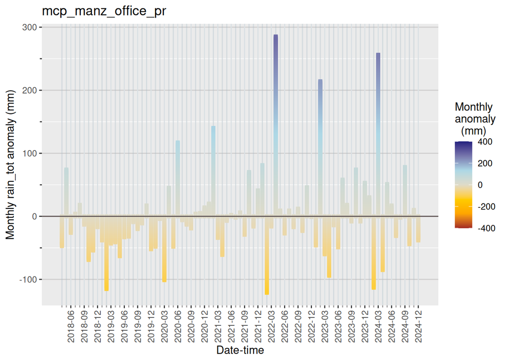

```r
p <- plot_m_anomaly(pipe_house = pipe_house, phen_name = "rain_tot",
  phen_units = "mm"
)
p$plt[[3]]
```

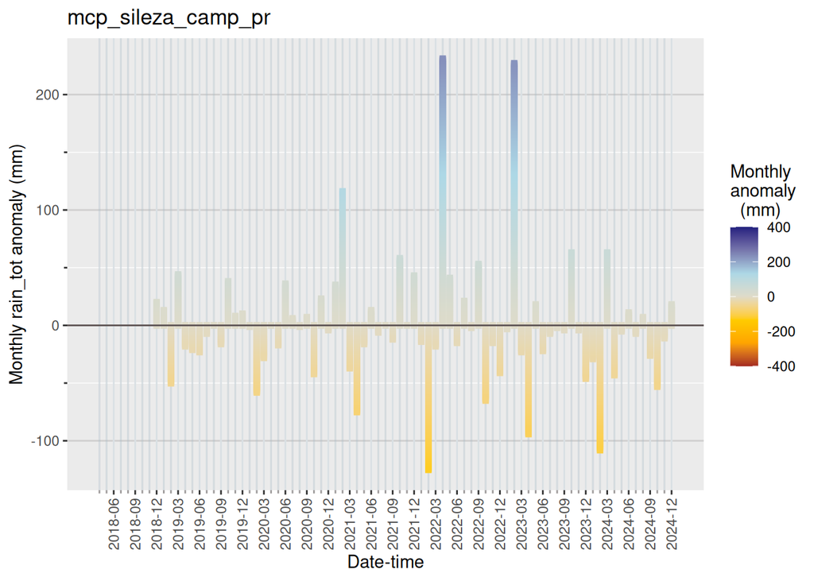

```r
p$plt[[4]]
```

# The rainfall ‘pipe_seq’

It’s not necessary to understand the detail of each function that builds the `pipe_seq` object below. However, for cusomising these functions, more info can be found in each function’s helpfile descriptions, e.g., type `?pipe_seq` in your R console. The `pipe_seq` table from the station file processed above is shown below. Note function parameters (‘f_params’) are described for each stage (‘dt_n’) and nested steps (‘dtp_n’). The function for each stage’s step are in the ‘f’ column. This pipe sequence table makes it easier to inspect the data processing pipeline. When this table was evaluated by `dt_drocess_batch()` further parameters were produced for each respective function and stored in the station file objects.

```r
# using kableExtra
kbl(sf$pipe_seq) |> kable_paper("hover") |> kable_styling(font_size = 11) |>
  scroll_box(width = "100%", height = "180px")
```

| dt_n | dtp_n | n | f | f_params | input_dt | output_dt | time_interval | start_dttm | end_dttm |
| --- | --- | --- | --- | --- | --- | --- | --- | --- | --- |
| 1 | 1 | 1 | dt_harvest | hsf_param_eval(hsf_table = “meta_events”) | meta_events | dt_pseudo_event | discnt | NA | NA |
| 1 | 2 | 1 | dt_calc | dt[event_type == ‘pseudo_events’, ] | dt_pseudo_event | dt_pseudo_event | discnt | NA | NA |
| 1 | 2 | 2 | dt_calc | [stnd_title == station, ] | dt_pseudo_event | dt_pseudo_event | discnt | NA | NA |
| 1 | 2 | 3 | dt_calc | [qa == TRUE, ] | dt_pseudo_event | dt_pseudo_event | discnt | NA | NA |
| 2 | 1 | 1 | dt_harvest | hsf_param_eval(hsf_table = “raw_rain”) | raw_rain | dt_rain_se | discnt | NA | NA |
| 2 | 2 | 1 | dt_calc | dt[, fktest := fifelse(.I == 1 \| .I == .N, TRUE, FALSE)] | dt_rain_se | dt_rain_se | discnt | NA | NA |
| 2 | 2 | 2 | dt_calc | [fktest == TRUE, ] | dt_rain_se | dt_rain_se | discnt | NA | NA |
| 2 | 2 | 3 | dt_calc | [, rain_mm := rain_cumm, ipip(measure = “tot”, units = “mm”, var_type = “num”)] | dt_rain_se | dt_rain_se | discnt | NA | NA |
| 2 | 2 | 4 | dt_calc | [, rain_mm := 0] | dt_rain_se | dt_rain_se | discnt | NA | NA |
| 2 | 2 | 5 | dt_calc | [, .(date_time, rain_mm)] | dt_rain_se | dt_rain_se | discnt | NA | NA |
| 3 | 1 | 1 | dt_harvest | hsf_param_eval(hsf_table = “dt_rain_se”) | dt_rain_se | dt_rain_se | discnt | NA | NA |
| 3 | 2 | 1 | dt_calc | dt[, fktest := fifelse(.I == 1 \| .I == .N, TRUE, FALSE)] | dt_rain_se | dt_rain_se | discnt | NA | NA |
| 3 | 2 | 2 | dt_calc | [fktest == TRUE, ] | dt_rain_se | dt_rain_se | discnt | NA | NA |
| 3 | 2 | 3 | dt_calc | [, rain_mm := 0] | dt_rain_se | dt_rain_se | discnt | NA | NA |
| 3 | 2 | 4 | dt_calc | [, .(date_time, rain_mm)] | dt_rain_se | dt_rain_se | discnt | NA | NA |
| 4 | 1 | 1 | dt_harvest | hsf_param_eval(hsf_table = “raw_rain”) | raw_rain | dt_rain | discnt | NA | NA |
| 4 | 2 | 1 | dt_calc | dt[!is.na(rain_cumm), ] | dt_rain | dt_rain | discnt | NA | NA |
| 4 | 2 | 2 | dt_calc | [, rain_diff := c(0, rain_cumm[2:.N] - rain_cumm[1:(.N - 1)]), ipip(measure = “tot”, units = “mm”, var_type = “num”)] | dt_rain | dt_rain | discnt | NA | NA |
| 4 | 2 | 3 | dt_calc | [rain_diff != 0, ] | dt_rain | dt_rain | discnt | NA | NA |
| 4 | 2 | 4 | dt_calc | [, t_lag := c(0, date_time[2:.N] - date_time[1:(.N - 1)]), ipip(measure = “tot”, units = “sec”, var_type = “num”)] | dt_rain | dt_rain | discnt | NA | NA |
| 4 | 3 | 1 | dt_harvest | hsf_param_eval(hsf_table = “logg_interfere”) | logg_interfere | dt_rain | discnt | NA | NA |
| 4 | 4 | 1 | dt_join | join_param_eval(fuzzy = c(0, 600), full_eval = FALSE, join = “left_join”) | dt_rain | dt_rain | discnt | NA | NA |
| 4 | 5 | 1 | dt_harvest | hsf_param_eval(hsf_table = “dt_pseudo_event”) | dt_pseudo_event | dt_rain | discnt | NA | NA |
| 4 | 6 | 1 | dt_join | join_param_eval(fuzzy = 0, full_eval = FALSE, join = “left_join”, y_key = c(“start_dttm”, “end_dttm”)) | dt_rain | dt_rain | discnt | NA | NA |
| 4 | 7 | 1 | dt_calc | dt[, false_tip_type := fifelse(logg_interfere_type %in% ‘on_site’, ‘interfere’, NA_character_), ipip(measure = “smp”, units = “false_tip”, var_type = “chr”)] | dt_rain | dt_rain | discnt | NA | NA |
| 4 | 7 | 2 | dt_calc | [, false_tip_type := fifelse(is.na(false_tip_type) & event_type %in% ‘pseudo_events’,‘pseudo_event’, false_tip_type)] | dt_rain | dt_rain | discnt | NA | NA |
| 4 | 7 | 3 | dt_calc | [, false_tip_type := fifelse(t_lag == 1, ‘double_tip’, false_tip_type)] | dt_rain | dt_rain | discnt | NA | NA |
| 4 | 7 | 4 | dt_calc | [, false_tip := fifelse(!is.na(false_tip_type), TRUE, FALSE), ipip(measure = “smp”, units = “false_tip”, var_type = “logi”)] | dt_rain | dt_rain | discnt | NA | NA |
| 4 | 7 | 5 | dt_calc | [, false_tip := fifelse(problem_gap %in% FALSE, FALSE, false_tip)] | dt_rain | dt_rain | discnt | NA | NA |
| 4 | 7 | 6 | dt_calc | [, false_tip := fifelse(is.na(false_tip), FALSE, false_tip)] | dt_rain | dt_rain | discnt | NA | NA |
| 4 | 7 | 7 | dt_calc | [, .(date_time, rain_cumm, rain_diff, false_tip, false_tip_type, problem_gap)] | dt_rain | dt_rain | discnt | NA | NA |
| 4 | 7 | 8 | dt_calc | [false_tip == FALSE, .(date_time, false_tip, false_tip_type, problem_gap), ipip(fork_table = “pseudo_events”)] | dt_rain | dt_rain | discnt | NA | NA |
| 4 | 7 | 9 | dt_calc | [, .(date_time)] | dt_rain | dt_rain | discnt | NA | NA |
| 4 | 7 | 10 | dt_calc | [, rain_mm := 0.254, ipip(measure = “tot”, units = “mm”, var_type = “num”)] | dt_rain | dt_rain | discnt | NA | NA |
| 5 | 1 | 1 | dt_harvest | hsf_param_eval(hsf_table = “dt_rain”) | dt_rain | dt_rain | discnt | NA | NA |
| 5 | 2 | 1 | dt_calc | dt[!rain_mm == 0, ] | dt_rain | dt_rain | discnt | NA | NA |
| 5 | 3 | 1 | dt_harvest | hsf_param_eval(hsf_table = “dt_rain_se”) | dt_rain_se | dt_rain | discnt | NA | NA |
| 5 | 4 | 1 | dt_join | join_param_eval(full_eval = FALSE, join = “full_join”) | dt_rain | dt_rain | discnt | NA | NA |
| 6 | 1 | 1 | dt_harvest | hsf_param_eval(hsf_table = “gaps”) | gaps | dt_gaps_tmp | discnt | NA | NA |
| 6 | 2 | 1 | dt_calc | dt[problem_gap == TRUE, .(gap_start, gap_end, problem_gap)] | dt_gaps_tmp | dt_gaps_tmp | discnt | NA | NA |
| 7 | 1 | 1 | dt_harvest | hsf_param_eval(hsf_table = “dt_rain”) | dt_rain | dt_rain | discnt | NA | NA |
| 7 | 2 | 1 | dt_agg | agg_options(agg_intervals=c(“5_mins”,“1_hours”,“1_days”)) | dt_rain | dt_rain | discnt | NA | NA |
| 7 | 2 | 2 | dt_agg | agg_options(ignore_nas=TRUE) | dt_rain | dt_rain | discnt | NA | NA |
| 7 | 2 | 3 | dt_agg | agg_options(all_phens=FALSE) | dt_rain | dt_rain | discnt | NA | NA |
| 7 | 2 | 4 | dt_agg | aggs(rain_mm=.(phen_out_name=“rain_tot”,units=“mm”)) | dt_rain | dt_rain | discnt | NA | NA |
| 7 | 3 | 1 | dt_agg | agg_options(agg_intervals=“1_days”) | dt_rain | dt_rain | discnt | NA | NA |
| 7 | 3 | 2 | dt_agg | agg_options(agg_dt_suffix=“_agg_saws”) | dt_rain | dt_rain | discnt | NA | NA |
| 7 | 3 | 3 | dt_agg | agg_options(ignore_nas=TRUE) | dt_rain | dt_rain | discnt | NA | NA |
| 7 | 3 | 4 | dt_agg | agg_options(all_phens=FALSE) | dt_rain | dt_rain | discnt | NA | NA |
| 7 | 3 | 5 | dt_agg | agg_options(agg_offset=“8hours”) | dt_rain | dt_rain | discnt | NA | NA |
| 7 | 3 | 6 | dt_agg | aggs(rain_mm=.(phen_out_name=“rain_tot”,units=“mm”)) | dt_rain | dt_rain | discnt | NA | NA |
| 8 | 1 | 1 | dt_harvest | hsf_param_eval(hsf_table = “dt_1_days_agg”) | dt_1_days_agg | dt_discnt | discnt | NA | NA |
| 8 | 2 | 1 | dt_agg | agg_options(agg_intervals=c(“1_months”,“1_years”)) | dt_discnt | dt_discnt | discnt | NA | NA |
| 8 | 2 | 2 | dt_agg | agg_options(ignore_nas=TRUE) | dt_discnt | dt_discnt | discnt | NA | NA |

The rainfall-data pipeline was build using the following script. This pipe sequence can be adjusted and re-embedded into a station file at any time.

```r
library(ipayipi)
#' Pipeline rainfall data processing sequence
#' v1.00
#' Last updated 2024-07-30
#'
#' Summary
#' The pipe sequence is documented as `pipe_seq` below. First calculation
#'  parameters are defined as consequtively numbered 'x' variables. These
#'  are used in the `pipe_seq` object.
#' This `pipe_seq` cleans/processes rainfall data from automatic tipping-
#' bucket rainguages. Data processed into the folling time
#' interval aggregations; "5 mins", "hourly", "daily", "monthly", and "yearly".
#' For compatibility with SAWS an eight hour offest is provided in addition to
#' the standard daily aggregation.

# define constants ----
#' general tipping bucket pipeline sequence for rainfall data
rain_tip <- 0.254 #' value in mm of a single tip-bucket tip

# calc parameters -> passed to `calc_param_eval()` ----
#' filter the events data based to extract 'pseudo events' (i.e., false tips)
#' Pseudo events
x12 <- list(
  pseudo_ev1 = chainer(dt_syn_bc = "event_type == \'pseudo_events\'"),
  pseudo_ev2 = chainer(dt_syn_bc = "stnd_title == station"),
  pseudo_ev3 = chainer(dt_syn_bc = "qa == TRUE")
)
#' create a start and end date_time -- necessary for discontinuous data
#' this will be appended to the discontinuous data series before data
#' aggregation
x22 <- list(
  fork_se1 = chainer(
    dt_syn_ac = "fktest := fifelse(.I == 1 | .I == .N, TRUE, FALSE)"
  ),
  fork_se2 = chainer(dt_syn_bc = "fktest == TRUE"),
  fork_se3 = chainer(dt_syn_ac = "rain_mm := rain_cumm",
    measure = "tot", units = "mm", var_type = "num"
  ),
  fork_se4 = chainer(dt_syn_ac = "rain_mm := 0"),
  fork_se5 = chainer(dt_syn_ac = ".(date_time, rain_mm)")
)
#' repeat the above after it was written to dt_rain_se in chunked data
x32 <- list(
  fork_se1 = chainer(
    dt_syn_ac = "fktest := fifelse(.I == 1 | .I == .N, TRUE, FALSE)"
  ),
  fork_se2 = chainer(dt_syn_bc = "fktest == TRUE"),
  fork_se4 = chainer(dt_syn_ac = "rain_mm := 0"),
  fork_se5 = chainer(dt_syn_ac = ".(date_time, rain_mm)")
)
#' remove double tips (tips one second after the previous)
x42 <- list(
  logg_remove1 = chainer(dt_syn_bc = "!is.na(rain_cumm)"),
  rain_diff = chainer(
    dt_syn_ac = "rain_diff := c(0, rain_cumm[2:.N] - rain_cumm[1:(.N - 1)])",
    measure = "tot", units = "mm", var_type = "num"
  ),
  rain_diff_remove = chainer(dt_syn_bc = "rain_diff != 0"),
  t_lag = chainer(
    dt_syn_ac = "t_lag := c(0, date_time[2:.N] - date_time[1:(.N - 1)])",
    measure = "tot", units = "sec", var_type = "num"
  )
)
#' summarise pseudo events--false tips
x47 <- list(
  false_tip_type1 = chainer(dt_syn_ac = paste0("false_tip_type := fifelse(",
      "logg_interfere_type %in% \'on_site\', \'interfere\', NA_character_)"
    ), temp_var = FALSE, measure = "smp", units = "false_tip", var_type = "chr"
  ),
  false_tip_type2 = chainer(dt_syn_ac = paste0("false_tip_type := fifelse(",
    "is.na(false_tip_type) & event_type %in% \'pseudo_events\',",
    "\'pseudo_event\', false_tip_type)"
  )),
  false_tip_type3 = chainer(dt_syn_ac = paste0("false_tip_type := ",
    "fifelse(t_lag == 1, \'double_tip\', false_tip_type)"
  )),
  false_tip4 = chainer(
    dt_syn_ac = "false_tip := fifelse(!is.na(false_tip_type), TRUE, FALSE)",
    temp_var = FALSE, measure = "smp", units = "false_tip", var_type = "logi"
  ),
  false_tip5 = chainer(dt_syn_ac =
      "false_tip := fifelse(problem_gap %in% FALSE, FALSE, false_tip)"
  ),
  false_tip6 = chainer(
    dt_syn_ac = "false_tip := fifelse(is.na(false_tip), FALSE, false_tip)"
  ),
  clean_up1 = chainer(dt_syn_ac = paste0(".(date_time, rain_cumm, rain_diff, ",
    "false_tip, false_tip_type, problem_gap)"
  )),
  false_tip_table = chainer(dt_syn_bc = "false_tip == FALSE",
    dt_syn_ac = ".(date_time, false_tip, false_tip_type, problem_gap)",
    fork_table = "pseudo_events"
  ),
  clean_up2 = chainer(dt_syn_ac = paste0(".(date_time)")),
  rain_mm = chainer(dt_syn_ac = paste0("rain_mm := ", rain_tip),
    measure = "tot", units = "mm", var_type = "num"
  )
)
#' remove old start end date-time values
x52 <- list(clean_se = chainer(dt_syn_bc = "!rain_mm == 0"))
#' filter gaps before joining --- only want 'problem gaps'
x62 <- list(pgap = chainer(dt_syn_bc = "problem_gap == TRUE",
  dt_syn_ac = ".(gap_start, gap_end, problem_gap)"
))

# build pipe sequence ----
#' this builds the table from the described parameters that will be evaluated
#' to generate parameters for processing the data
pipe_seq <- pipe_seq(p = pdt(
  # extract pseudo events
  p_step(dt_n = 1, dtp_n = 1, f = "dt_harvest",
    f_params = hsf_param_eval(hsf_table = "meta_events"),
    output_dt = "dt_pseudo_event"
  ),
  p_step(dt_n = 1, dtp_n = 2, f = "dt_calc",
    f_params = calc_param_eval(x12),
    output_dt = "dt_pseudo_event"
  ),
  #' create 'fork_se'
  #' the fork start and end date-time will be appended to data before
  #' time interval aggregations---NB for event data
  #' this feeds the aggregation function the full range of data to
  #' be aggregated. Without this the leading and training time where events
  #' aren't logged will be cut short from the aggregation
  p_step(dt_n = 2, dtp_n = 1, f = "dt_harvest",
    f_params = hsf_param_eval(hsf_table = "raw_rain"),
    output_dt = "dt_rain_se"
  ),
  p_step(dt_n = 2, dtp_n = 2, f = "dt_calc",
    f_params = calc_param_eval(x22),
    output_dt = "dt_rain_se"
  ),
  # join 'fork_se' with old 'fork_se'
  p_step(dt_n = 3, dtp_n = 1, f = "dt_harvest",
    f_params = hsf_param_eval(hsf_table = "dt_rain_se"),
    output_dt = "dt_rain_se"
  ),
  p_step(dt_n = 3, dtp_n = 2, f = "dt_calc",
    f_params = calc_param_eval(x32),
    output_dt = "dt_rain_se"
  ),
  # find 'double tips'
  p_step(dt_n = 4, dtp_n = 1, f = "dt_harvest",
    f_params = hsf_param_eval(hsf_table = "raw_rain"),
    output_dt = "dt_rain"
  ),
  p_step(dt_n = 4, dtp_n = 2, f = "dt_calc",
    f_params = calc_param_eval(x42),
    output_dt = "dt_rain"
  ),
  # get interference events
  p_step(dt_n = 4, dtp_n = 3, f = "dt_harvest",
    f_params = hsf_param_eval(hsf_table = "logg_interfere"),
    output_dt = "dt_rain"
  ),
  p_step(dt_n = 4, dtp_n = 4, f = "dt_join",
    f_params = join_param_eval(join = "left_join", fuzzy = c(0, 600))
  ),
  # add pseudo events
  p_step(dt_n = 4, dtp_n = 5, f = "dt_harvest",
    f_params = hsf_param_eval(hsf_table = "dt_pseudo_event"),
    output_dt = "dt_rain"
  ),
  p_step(dt_n = 4, dtp_n = 6, f = "dt_join",
    f_params = join_param_eval(join = "left_join", fuzzy = 0,
      y_key = c("start_dttm", "end_dttm")
    ), output_dt = "dt_rain"
  ),
  p_step(dt_n = 4, dtp_n = 7, f = "dt_calc",
    f_params = calc_param_eval(x47),
    output_dt = "dt_rain"
  ),
  p_step(dt_n = 5, dtp_n = 1, f = "dt_harvest",
    f_params = hsf_param_eval(hsf_table = "dt_rain"),
    output_dt = "dt_rain"
  ),
  p_step(dt_n = 5, dtp_n = 2, f = "dt_calc",
    f_params = calc_param_eval(x52),
    output_dt = "dt_rain"
  ),
  p_step(dt_n = 5, dtp_n = 3, f = "dt_harvest",
    f_params = hsf_param_eval(hsf_table = "dt_rain_se"),
    output_dt = "dt_rain"
  ),
  p_step(dt_n = 5, dtp_n = 4, f = "dt_join",
    join_param_eval(), output_dt = "dt_rain"
  ),
  p_step(dt_n = 6, dtp_n = 1, f = "dt_harvest",
    hsf_param_eval(hsf_table = "gaps"),
    output_dt = "dt_gaps_tmp"
  ),
  p_step(dt_n = 6, dtp_n = 2, f = "dt_calc",
    calc_param_eval(x62), output_dt = "dt_gaps_tmp"
  ),
  # aggregate data
  p_step(dt_n = 7, dtp_n = 1, f = "dt_harvest",
    hsf_param_eval(hsf_table = "dt_rain"),
    output_dt = "dt_rain"
  ),
  p_step(dt_n = 7, dtp_n = 2, f = "dt_agg",
    agg_param_eval(
      agg_intervals = c("5 mins", "hourly", "daily"),
      ignore_nas = TRUE, all_phens = FALSE,
      agg_parameters = aggs(
        rain_mm = agg_params(units = "mm", phen_out_name = "rain_tot")
      )
    )
  ),
  # saws daily data aggregation
  p_step(dt_n = 7, dtp_n = 3, f = "dt_agg",
    agg_param_eval(
      agg_offset = "8 hours",
      agg_intervals = c("daily"),
      ignore_nas = TRUE,
      all_phens = FALSE,
      agg_parameters = aggs(
        rain_mm = agg_params(units = "mm", phen_out_name = "rain_tot")
      ),
      agg_dt_suffix = "_agg_saws"
    )
  ),
  p_step(dt_n = 8, dtp_n = 1, f = "dt_harvest",
    hsf_param_eval(hsf_table = "dt_1_days_agg")
  ),
  p_step(dt_n = 8, dtp_n = 2, f = "dt_agg",
    agg_param_eval(
      agg_intervals = c("monthly", "yearly"),
      ignore_nas = TRUE
    )
  )
))
```

When running the pipe sequence we choose what portion of it to run by limiting the `stages` argument in `dt_process_batch()`—we can’t run the latter stages though without the former. This allows interruption of processing for imputing data etc.

# Tips for working in ‘ipayipi’

- Processing functions have filter keywords for limiting the scope of data being processed allowing the use to drill down on a subset of particular stations. The filter keywords are ‘regex’ based and parsed as ‘wanted’ and ‘unwanted’ arguments to most ‘ipayipi’ functions.
- It makes sense to start with on station or fewer files to learn how the process works before processing to much data.
- Set ‘prompt’ to TRUE for interactive selection of stations.
- Data chunking: station files are chunked and indexed by default in temporary memory within an R session. At the start of the R session there may be a delay in processing as files are ‘decompressed’ into chunks. To avoid the start-up cost of chunking, the chunk directory can be set out of temporary memory, e.g., `options(chunk_dir = "~/ipip")`.
- By default processing is done ‘sequentially’, however, using the ‘future’ framework parallel processing has been built into ‘ipayipi’ and is activated by setting `plan(multisession)` on Windows or `plan(multicore)` on Linux or MacOS. NB! Running in parallel will disable any interactive prompts, and may limit function message/error reporting. Something to be aware of. Also, running a ‘multisession’ is not always efficient. Test out various options as speed will be influenced by load bearing and your local system. Running on ‘multisession’ may produce errors that don’t occur when `plan(sequential, split = TRUE)` is called.